# Évolution des préoccupations du régime international des déchets

### Recherche sur l’évolution temporelle des sous-régimes des déchets à partir du cas de la Convention de Bâle

*par Jeanne Desrosiers*

#### Question de recherche et hypothèse

##### Question de recherche

Avec les évolutions dans les modes de production et de consommation au courant des dernières décennies, les résidus issus de ces activités, les déchets, ont varié de manière importante en nature et en quantité. Alors que de nouvelles exigences en matière de gestion et de réduction des déchets émergent à travers la diffusion du paradigme de l’[économie circulaire](https://vitrinelinguistique.oqlf.gouv.qc.ca/fiche-gdt/fiche/26560537/economie-circulaire) et l’institutionnalisation de responsabilité concernant les déchets à travers, notamment l’[objectif de développement durable 12 des Nations Unies](https://www.un.org/sustainabledevelopment/fr/sustainable-consumption-production/), les préoccupations concernant les déchets sont amenées à varier, tant à l’échelle nationale qu’à l’échelle internationale, entraînant ainsi un besoin de concertation renouvelé sur la question. En ce sens, il devient donc important d’avoir des pistes pour répondre à la question suivante : comment les préoccupations ou les priorités du régime des déchets évoluent-elles?

##### Revue de la littérature

Concernant l’évolution d’un régime international en environnement, celle-ci présente nécessairement une dimension temporelle, par les échéanciers considérables des négociations internationales qui entraînent des périodes de latence importantes avant d’arriver à des changements au texte fondamental. Une telle évolution, bien qu’elle puisse être étudiée depuis divers points de vue, doit ainsi avant tout être étudiée sous cet angle et à travers des cas qui permettent cette granularité temporelle, sachant qu’un changement de disposition légale en la matière peut prendre près d’une décennie (Berkowitz et al., 2003, p. 164‑165). Cette évolution dans le temps ne doit cependant pas être vue comme une avancée linéaire. Au contraire, les traités internationaux, et donc leur contenu, sont sujets à des dynamiques d’influence diversifiées et parfois opposées et se trouvent impliqués dans des cycles de modification ou de négociation parfois concurrents. Les parties prenantes du traité et leurs comportements se révèlent ainsi cruciaux comme forces motrices dans les itérations du régime et de ses traités (Bloomfield, 2016; Finnemore & Sikkink, 1998; Moore, 2012). Ces acteurs interviennent tout particulièrement pour pousser de nouveaux enjeux sur la scène internationale, en vertu des théories de l’apprentissage, en fonction de leurs expériences ou des expériences de leurs voisins. Vivre les problématiques semble essentiel à leur cadrage en enjeux au sein des négociations par les États concernés (Dobbin et al., 2007; Gönenç, 2021).

Concernant précisément le régime international des déchets, celui-ci est principalement basé sur la Convention de Bâle, au long *Basel Convention on the Control of Transboundary Movements of Hazardous Wastes and Their Disposal*, étant le seul traité de portée internationale à cibler spécifiquement la gestion des déchets et étant également le repositoire de la définition de ce qui constitue un déchet pour l’ensemble des autres dispositions juridiques internationales sur la question (Peiry, 2013). Cette Convention est perçue comme particulièrement dynamique de par la nature volontaire de son approche et de sa portée régulatrice (Busch et al., 2005; Wiprächtiger et al., 2021). Elle serait sensible à des changements dans le contexte international, comme l’avènement de l’économie circulaire qui force la diminution des déchets destinés à l’incinération ou à l’enfouissement et ainsi à la fois une réduction des déchets produits, mais aussi une gestion optimisée de ceux-ci (Zeng et al., 2022). En effet, la Convention de Bâle serait dans une recherche constante d’adaptations afin de rester pertinente malgré les changements paradigmatiques concernant le traitement des déchets (Setiawan, 2024). Ainsi, à travers son vocable «other wastes», qui lui permet de dépasser le cadre des déchets dangereux, la Convention a tenté et tente toujours d’intégrer de nouvelles familles de déchets à son traité pour mieux en gérer la production et l’élimination, avec des résultats demeurant mitigés jusqu’à maintenant (Awasthi et al., 2019; Khan, 2016; Ogunseitan, 2013; Setiawan, 2024; Van Der Marel, 2022).

##### Hypothèse

L’hypothèse de ce travail serait donc que la Convention de Bâle évolue en termes de couverture de déchets selon les propositions dérivées des expériences vécues par les États. Celle-ci découle d’une revue de littérature réaliséee par la technique *boule de neige* dans une recherche par Google Scholar, dont les sources pertinentes recueillies ont été collectées et classées en fonction de leur sujet dans Zotero.

#### Collecte de données

##### Méthodologie

Afin de tester l’hypothèse énoncée ci-dessus, la fréquence des mots-clés associés aux différents types de déchets sera mesurée à travers le temps par le biais des comptes-rendus des conférences des parties (COP) du Secrétariat de la Convention. Pour ce faire, les comptes-rendus ont été téléchargés sous forme de fichiers .pdf à partir du site web de la Convention (Secretariat of the Basel Convention, s. d.). Dans un premier temps pour repérer les termes associés aux types de déchets à prendre en compte, une première analyse de la fréquence des mots a été réalisée dans R à l’aide des packages *pdftools*, pour extraire le texte des fichiers, *tm*, *tidyverse* et *textclean* pour le nettoyage et la manipulation du texte, puis finalement *quanteda* et *quantedatextstats* pour réaliser l’analyse textuelle de la fréquence des mots. Cette première étape a permis de regrouper les mots-clés revenant les plus fréquemment concernant les types de déchets en 15 types basés sur la famille des déchets, dont les appellations sont conservées en anglais pour éviter toute confusion : *chemicals*, *e-waste*, *plastics*, *microplastics*, *resins*, *batteries*, *household*, *nanomaterials*, *metals*, *oils*, *biomedical*, *pesticides*, *rubber*, *mercury*, *persistent organics pollutants* (*POPs*). Une fois cette première étape complétée, vu l’impossibilité du package *pdftools* à extraire le texte de fichiers .pdf scannés et l’insuffisante performance de l’outil *ocr*, soit reconnaissance optique de caractères, du package *tesseract*, les fichiers .pdf ont été analysés avec l’outil *scan et ocr* d’Adobe et les termes clés identifiés lors de la première ronde d’analyse furent comptabilisés manuellement dans Excel. Le code pour réaliser l’analyse de la fréquence de mots a été rédigé avec l’assistance de ChatGPT d’OpenAI.

##### Résultats

*Tableau des résultats: Fréquences des mentions des sous-régimes aux Conférences des Parties*

| Type | COP1 | COP2 | COP3 | COP4 | COP5 | COP6 | COP7 | COP8 | COP9 | COP10 | COP11 | COP12 | COP13 | COP14 | COP15 | COP16 |
| --- | --- | --- | --- | --- | --- | --- | --- | --- | --- | --- | --- | --- | --- | --- | --- | --- |
| Chemicals | 2 | 7 | 1 | 17 | 19 | 40 | 40 | 48 | 33 | 130 | 52 | 130 | 161 | 96 | 203 | 157 |
| E-waste | 0 | 0 | 0 | 13 | 0 | 39 | 11 | 145 | 55 | 47 | 49 | 80 | 86 | 122 | 126 | 89 |
| Plastics | 0 | 2 | 0 | 9 | 8 | 12 | 23 | 4 | 0 | 1 | 3 | 0 | 18 | 127 | 135 | 113 |
| Microplastics | 0 | 0 | 0 | 0 | 0 | 0 | 0 | 0 | 0 | 0 | 0 | 0 | 11 | 22 | 8 | 4 |
| Resins | 0 | 0 | 0 | 8 | 0 | 1 | 0 | 0 | 0 | 0 | 0 | 0 | 0 | 20 | 0 | 0 |
| Batteries | 0 | 0 | 0 | 10 | 1 | 20 | 5 | 9 | 1 | 2 | 1 | 1 | 4 | 18 | 39 | 33 |
| Household waste | 1 | 1 | 0 | 0 | 0 | 2 | 5 | 11 | 6 | 1 | 1 | 21 | 35 | 27 | 20 | 27 |
| Nanomaterials | 0 | 0 | 0 | 0 | 0 | 0 | 0 | 0 | 0 | 0 | 0 | 0 | 8 | 30 | 22 | 13 |
| Metals | 3 | 8 | 2 | 40 | 6 | 90 | 26 | 4 | 2 | 2 | 0 | 0 | 1 | 2 | 0 | 1 |
| Oils | 1 | 5 | 0 | 4 | 1 | 23 | 4 | 33 | 1 | 3 | 1 | 1 | 4 | 4 | 6 | 4 |
| Biomedical waste | 0 | 0 | 0 | 1 | 3 | 14 | 7 | 8 | 6 | 3 | 0 | 1 | 3 | 2 | 0 | 1 |
| Pesticides | 0 | 0 | 0 | 4 | 11 | 10 | 19 | 36 | 13 | 12 | 8 | 18 | 19 | 16 | 51 | 37 |
| Rubber | 0 | 0 | 0 | 6 | 4 | 0 | 0 | 3 | 30 | 7 | 7 | 0 | 1 | 2 | 10 | 28 |
| Mercury | 0 | 0 | 0 | 10 | 0 | 2 | 11 | 17 | 23 | 31 | 27 | 26 | 19 | 32 | 52 | 22 |
| POPs | 0 | 0 | 0 | 6 | 13 | 26 | 33 | 34 | 25 | 72 | 46 | 59 | 50 | 42 | 56 | 56 |

#### Analyse et visualisation de données

##### Visualisation

Ces données ont été comptabilisées manuellement dans Excel et ensuite entrées dans R sous forme de vecteurs par sous-régime combinés dans un data frame qui a permis la visualisation de l’évolution de chacun de ces sous-régimes de déchets, grâce aux packages *ggplot2*, *dplyr* et *tidyr*, avec la réalisation d’un graphique linéaire. Le code pour réaliser le graphique a été rédigé avec l’assistance de ChatGPT d’OpenAI. Le graphique linéaire produit, où l’axe des x représente chacune des COPs, l’axe des y la fréquence des mots associés aux sous-régimes dans le texte et chaque ligne un sous-régime, permet de bien saisir les variations des fréquences des mots dans le temps et ainsi l’importance qu’un sous-régime a pu avoir lors des différentes conférences.

*Graphique: Évolution des sous-régimes des déchets à travers les Conférences des Parties de la Convention de Bâle*

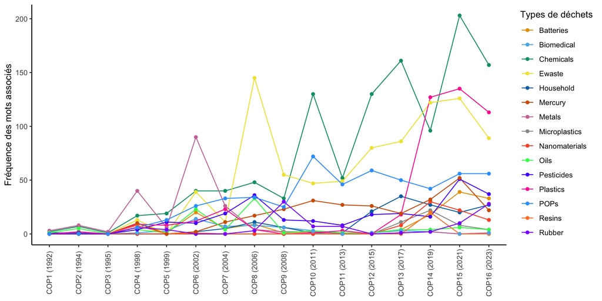

##### Analyse

Cette visualisation nous permet de faire ressortir différentes tendances évolutives des sous-régimes, mais également de la Convention, qui devraient être approfondies davantage dans des travaux subséquents. Pour ce qui est des sous-régimes, il semblerait que cinq types d’évolution puissent être identifiés. Il y aurait les régimes sporadiques, qui sont peu abordés en général, mais qui vont connaître de petites poussées dans leurs fréquences à certains moments précis. On pourrait croire qu’ils sont associés à des interventions de certains États sur le sujet, mais que la portée de l’enjeu demeure limitée, car ils préoccupent peu d’États dans leur gestion nationale des déchets ou sont très limités dans leur portée. Des exemples seraient les sous-régimes des *microplastics*, *nanomaterials*, *biomedical waste* et *resins*.

Il y aurait ensuite les régimes à impulsion de courte durée. Ceux-ci vont connaître des hausses remarquables, sans être massives, dans leurs mentions avec une portée sur une ou deux COPs consécutives. Une hypothèse serait que ces changements seraient liés au contexte international, donc à des évènements ou incidents environnementaux qui créent un stress sur ces sous-régimes. Les exemples ici seraient les sous-régimes *metals*, *oils* et *rubber*. D’un autre côté, il y aurait les régimes constants de fond, qui seraient des enjeux qui sont toujours discutés, qui connaissent des variations, mais qui demeurent relativement stables. Ce pourrait être les régimes des déchets *household*, du *mercury* et des *pesticides*. Ce seraient des sous-régimes qui concernent soit des déchets dont la production est toujours constante, comme les déchets domestiques, soit des déchets qui font l’objet de d’autres conventions ([Convention de Minamata](https://minamataconvention.org/fr) sur le mercure, [Convention de Rotterdam](https://www.pic.int/) sur les pesticides).

Finalement, il y aurait les régimes de croissance, qui constitueraient deux types. Les régimes de croissance explosive, après une forte impulsion dans le nombre de mentions, continuraient de croître progressivement ensuite, comme les sous-régimes *chemicals*, *plastics* et *e-waste*. On pourrait les associer à une proportion accrue dans l’ensemble des déchets étant donné des changements dans la production, mais aussi un constat des impacts négatifs qu’ils posent à grande échelle soutenu par de nombreuses preuves visibles frappantes. Les régimes de croissance par plateau, quant à eux, ont une croissance plus progressive, avec une stabilisation en plateau après une croissance modérée, l’exemple étant le sous-régime des *POPs*. Une explication possible résulterait de la combinaison de connaissances scientifiques des impacts de ce type de déchets en renouvellement continu avec la présence d’une autre Convention qui régulariserait la progression du régime ([Convention de Stockholm](https://chm.pops.int/) sur les POPs).

Finalement, il semblerait essentiel de souligner que cette analyse se veut exploratoire et donc que les tendances observées restent à étudier plus en profondeur. De plus, ces tendances ne sont pas mutuellement exclusives; un sous-régime peut passer par différentes tendances au courant de son existence, de-là l’importance d’étudier sous un angle temporel les conventions pour comprendre quels enjeux sont traités au niveau international et lesquels restent à la marge, à la fois pour mieux comprendre les relations interétatiques en environnement, mais également pour mieux concentrer nos efforts sur les enjeux qui nécessitent des actions, à la fois dû à une forte demande ou à une négligence sur la question (Bloomfield, 2016; Finnemore & Sikkink, 1998).

#### Discussion

Dans le cadre de ce travail, les outils suivants ont été utilisés : Google Scholar, Zotero, R, Adobe et ChatGPT. Le critère prioritaire qui a dirigé le choix de ces outils est l’accessibilité, l’adaptabilité et la compatibilité; il était essentiel pour moi que les outils que j’utilisais soient facilement utilisables, versatiles pour répondre à mes besoins et tous compatibles les uns avec les autres. Google Scholar et Zotero sont apparus comme des outils inévitables pour ma revue de littérature, étant donné l’utilisation quotidienne que j’en fait et ma grande aisance à les utiliser.

Ensuite, pour l’analyse des données, mon premier choix était d’utiliser uniquement R, du fait de la flexibilité, la transparence et l’indépendance qui venaient avec son utilisation. Cependant, dû à mon manque de connaissances des packages me permettant de réaliser des analyses de textes, j’ai fait appel à ChatGPT pour m’aider à rédiger mon code, car bien que son manque de transparence soit quelque peu contre mes valeurs, il demeure le meilleur outil pour accompagner la pratique du codage dans R, particulièrement pour la résolution d’erreurs. J’ai donc utilisé le package *pdftools* pour pouvoir extraire le texte de mes documents .pdf et le package *tesseract* pour sa fonction *ocr* afin d’extraire le texte des documents scannés. Les packages *tidyverse*, *tm* et *textclean* m’ont permis de nettoyer les textes pour les rendre prêts à l’analyse. Les packages *quanteda* et *quantedatextstats* m’ont permis de créer un corpus et de réaliser mes analyses de fréquences des mots avec lesquelles j’ai identifié les familles de mots correspondant à des sous-régimes de déchets.

Toutefois, lors de la réalisation de ma seconde analyse concentrée sur les régimes, j’ai remarqué que les occurrences étaient trop faibles pour certains documents, particulièrement pour les documents traités par la fonction *ocr*. Grâce à ChatGPT, j’ai pu comprendre que selon la qualité des documents scannés et possiblement les protections appliquées, la fonction d’*ocr* de *tesseract* n’était pas assez performante. Il m’a recommandé de me tourner vers un logiciel spécialisé. J’ai donc utilisé la fonction premium *Scan et OCR* d’Adobe, en profitant de la version d’essai gratuite, pour traiter mes fichiers .pdf et j’ai ensuite comptabilisé manuellement dans un fichier Excel les occurrences des sous-régimes. Cette limite vécue avec R vient possiblement de mon manque de connaissances, mais il demeure qu’Adobe, malgré un manque d’accessibilité lié à ses coûts, est réputé pour avoir la reconnaissance optique de caractères la plus perfectionnée pour les fichiers .pdf. Cependant, j’ai ensuite de nouveau travaillé avec R pour la visualisation des données, puisqu’il s’agit de l’option qui donne le plus de marge de manœuvre à l’utilisateur pour réaliser des graphiques personnalisés. J’ai encore été assisté de ChatGPT afin de rédiger le code et de l’ajuster pour que le graphique soit plus facilement lisible. Pour réaliser mon graphique linéraire, les packages *dplyr*, *tidyr* et *ggplot2* ont été mise à contribution.

En bref, ma démarche et le choix de mes outils ont été motivés par un désir que la science et les activités de recherche qu’elle implique soient accessibles, mais face à certains obstacles rencontrés, il m’a fallu revoir mes attentes et choisir certains outils qui me permettaient d’atteindre mes objectifs dans un échéancier et avec des efforts raisonnables.

#### Bibliographie

Awasthi, A. K., Li, J., Koh, L., & Ogunseitan, O. A. (2019). Circular economy and electronic waste. *Nature Electronics*, *2*(3), 86‑89. https://doi.org/10.1038/s41928-019-0225-2

Berkowitz, D., Pistor, K., & Richard, J.-F. (2003). The Transplant Effect. *The American Journal of Comparative Law*, *51*(1), 163‑204. https://doi.org/10.2307/3649143

Bloomfield, A. (2016). Norm antipreneurs and theorising resistance to normative change. *Review of International Studies*, *42*(2), 310‑333. https://doi.org/10.1017/S026021051500025X

Busch, P.-O., Jörgens, H., & Tews, K. (2005). The Global Diffusion of Regulatory Instruments: The Making of a New International Environmental Regime. *The ANNALS of the American Academy of Political and Social Science*, *598*(1), 146‑167. https://doi.org/10.1177/0002716204272355

Dobbin, F., Simmons, B., & Garrett, G. (2007). The Global Diffusion of Public Policies: Social Construction, Coercion, Competition, or Learning? *Annual Review of Sociology*, *33*(1), 449‑472. https://doi.org/10.1146/annurev.soc.33.090106.142507

Finnemore, M., & Sikkink, K. (1998). International Norm Dynamics and Political Change. *International Organization*, *52*(4), 887‑917. https://doi.org/10.1162/002081898550789

Gönenç, D. (2021). Conceptualizing norm fusion through environmental rights. *Environmental Politics*, *30*(3), 442‑461. https://doi.org/10.1080/09644016.2020.1743610

Khan, S. A. (2016). *E-products, E-waste and the Basel Convention: Regulatory Challenges and Impossibilities of International Environmental Law*. *25*(2), 248‑260. https://doi.org/10.1111/reel.12163

Moore, F. C. (2012). Negotiating Adaptation: Norm Selection and Hybridization in International Climate Negotiations. *Global Environmental Politics*, *12*(4), 30‑48. https://muse.jhu.edu/pub/6/article/488275

Ogunseitan, O. A. (2013). The Basel Convention and e-waste: translation of scientific uncertainty to protective policy. *The Lancet Global Health*, *1*(6), e313‑e314. https://doi.org/10.1016/S2214-109X(13)70110-4

Peiry, K. K. (2013). The Basel Convention on the Control of Transboundary Movements of Hazardous Wastes and their Disposal: The Basel Convention at a Glance. *Proceedings of the ASIL Annual Meeting*, *107*, 434‑436. https://doi.org/10.5305/procannmeetasil.107.0434

Secretariat of the Basel Convention. (s. d.). *Reports and Decisions. Basel Convention*. Consulté 5 décembre 2024, à l'adresse https://www.basel.int/TheConvention/ConferenceoftheParties/ReportsandDecisions/tabid/3303/Default.aspx

Setiawan, F. A. (2024). *The Basel Convention as an Evolving Treaty Regime: Implications of the Ban Amendment and Plastic Waste Amendment* [Thèse de doctorat, Kobe University]. https://hdl.handle.net/20.500.14094/0100477901

Van Der Marel, E. R. (2022). Trading Plastic Waste in a Global Economy: Soundly Regulated by the Basel Convention? *Journal of Environmental Law*, *34*(3), 477‑497. https://doi.org/10.1093/jel/eqac017

Wiprächtiger, M., Haupt, M., Rapp, M., & Hellweg, S. (2021). Waste not, want not – ambiguities around waste and waste prevention. *Resources, Conservation and Recycling*, *173*, 105742. https://doi.org/10.1016/j.resconrec.2021.105742

Zeng, X., Ogunseitan, O. A., Nakamura, S., Suh, S., Kral, U., Li, J., & Geng, Y. (2022). Reshaping global policies for circular economy. *Circular Economy*, *1*(1), 100003. https://doi.org/10.1016/j.cec.2022.100003